# BIOS 611 HW3 Exploratory Analysis, tibbles, and data import (Chapters 7, 10, and 11.2)

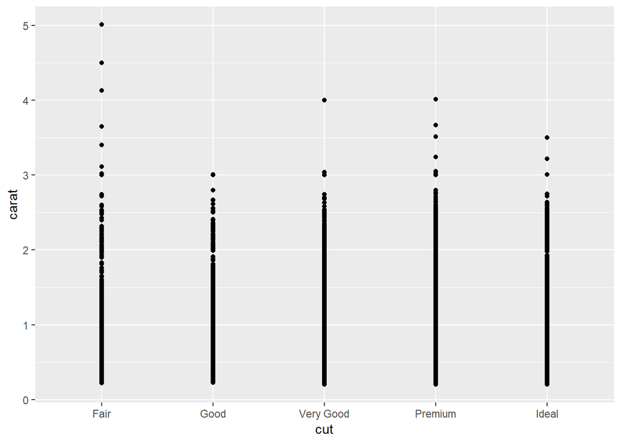

```r
ggplot(data=diamonds)+
  geom_point(aes(x=cut, y=carat))
```

Theres a lot of variablility within each cut for carat. There is a slights negative relationship between cut and carat. This can lead to lower quality diamonds being more expensive because smaller carat diamonds (which normally wouldn’t sell for as much as a higher carat diamond) has a higher cut, making it more expensive.

3. Install the ggstance package, and create a horizontal boxplot. (Use `geom_boxploth()`.) How does this compare to using `coord_flip()` in terms of syntax?

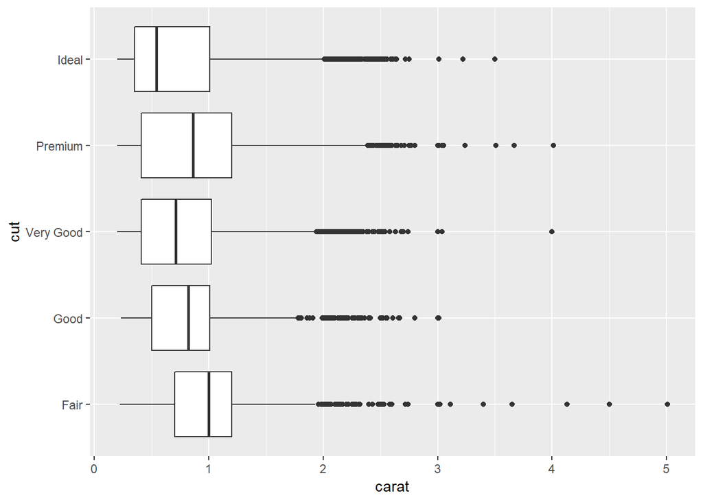

```r
ggplot(data=diamonds)+
  geom_boxploth(aes(y=cut, x=carat))
```

Using `coord_flip()` requires an extra line in code, along with thinking about where you want each variable on each axis and flipping it in the code, wereas when using `geom_boxploth()` the x and y axis are as written in the code.